# STAT 341: Assignment 1

DUE: Friday, January 26, 2024 by 5:00pm EST

$\;$ $\;$ $\;$ $\;$

## NOTES

Your assignment must be submitted by the due date listed at the top of this document, and it must be submitted electronically in .pdf format via Crowdmark. This means that your responses for different questions should begin on separate pages of your .pdf file. Note that your .pdf solution file must have been generated by R Markdown. Additionally:

- For mathematical questions: your solutions must be produced by LaTeX (from within R Markdown). Neither screenshots nor scanned/photographed handwritten solutions will be accepted – these will receive zero points.
- For computational questions: R code should always be included in your solution (via code chunks in R Markdown). If code is required and you provide none, you will receive zero points.
- For interpretation questions: plain text (within R Markdown) is required. Text responses embedded as comments within code chunks will not be accepted.

Organization and comprehensibility is part of a full solution. Consequently, points will be deducted for solutions that are not organized and incomprehensible. Furthermore, if you submit your assignment to Crowdmark, but you do so incorrectly in any way (e.g., you upload your Question 2 solution in the Question 1 box), you will receive a 5% deduction (i.e., 5% of the assignment’s point total will be deducted from your point total).

## QUESTION 1: Basic R Calculations [8 points]

The first lecture introduced `apply` functions as an alternative to using `for` loops in R. Implement the following tasks in R by using an appropriate `apply` function instead of a `for` loop. You may use *any* functions in `base` R to complete these tasks.

1. [2 points] Add 10 to each of the odd numbers in the following vector.

```r
part_a <- c(4, 9, 22, 25, 30, 34, 41, 53, 67, 98)

add_ten_to_odd <- function(num) {
  if (num %% 2 == 1) {
    return(num + 10)
  } else {
    return(num);
  }
}

ret <- apply(matrix(part_a), MARGIN=1, FUN=add_ten_to_odd)
```

2. [2 points] Determine how many entries in each row of the following matrix begin with the lowercase letter j.

```r
part_b <- matrix(c(letters, tolower(month.name[1:10])), nrow = 6)

find_num_start_j <- function(row) {
  sum(substr(row, 1, 1) == "j")
}

ret <- apply(part_b, MARGIN=1, FUN=find_num_start_j)
```

Later in the course, you will use more sophisticated techniques to minimize functions $g(x)$ or find solutions to the equation $g(x) = 0$. For the next two parts, solve these types of questions by naively evaluating $g(x)$ at various $x$ values. Get the `x` values for each question using the `seq(..., by=dx)` function. Notes:

- Using an extremely small `dx` will use a lot of computational resources, so press escape if a computation is taking too long and try something more moderate.
- You can check your work with calculus. Your answers should be within 0.001 of the correct answers.
3. [2 points] Approximate the value of $x$ that minimizes $g(x) = x^4 + x^3 + 2x^2 + 3x + 4$ on $-2 \le x \le 2$. Return the $(x, g(x))$ combination for this approximate solution.

```r
g <- function(x) {
  return (x^4 + x^3 + 2*x^2+3*x+4)
}
res <- optimize(g, interval=c(-2,2))
ans <- c(res$objective, res$minimum) # (2.77, -0.75)
```

4. [2 points] Approximate the value of $x$ that solves $g(x) = \dfrac{x^2 + x - 1}{x^2 + 2} = 0$ on $0 \le x \le 4$. Return the $(x, g(x))$ combination for this approximate solution.

```r
g <- function(x) {
  return((x^2+x-1) / (x^2+2))
}

root <- uniroot(g, interval=c(0,4))

ans <- c(root$root, 0) # (0.618, 0)
```

## QUESTION 2: Attributes with Kernel Density Estimators [11 points]

The beginning of this course emphasizes population attributes with a single variate: $\mathcal{P} = \{y_1, y_2, \ldots, y_N\}$. We often analyze this data under the assumption that $y_1, y_2, \ldots, y_N$ are generated independently and identically from some univariate distribution with density function $f$. [Kernel density estimation](https://en.wikipedia.org/wiki/Kernel_density_estimation) provides a flexible method to estimate this function $f$. Let’s suppose we want to estimate the value of $f$ at a given point $y_0$. The *kernel density estimator* (KDE) is
$$\hat{f}_h(y_0) = \dfrac{1}{N}\sum_{i =
1}^NK_h(y_0 - y_i),$$
where the non-negative function $K_h(\cdot)$ is called a *kernel* function that depends on a smoothing parameter $h > 0$ called the *bandwidth*. Essentially, the kernel function estimates $f$ by weighting contributions corresponding to each population unit such that units with variate values close to $y_0$ have larger $K_h(\cdot)$ values. We can therefore think of the KDE as a population attribute: $\hat{f}_h(y_0) = a(\mathcal{P}; y_0)$, where $a(\cdot)$ is a function of the population variates and the fixed point $y_0$.

We now consider the *Gaussian* kernel. For the Gaussian kernel, the function $K_h(\cdot)$ is the density function of a normal distribution with mean 0 and standard deviation corresponding to the bandwidth $h$:
$$K_h(v) =
\dfrac{1}{\sqrt{2\pi}h}\text{exp}\left(-\dfrac{1}{2}\left(\dfrac{v}{h}\right)^2\right).$$

Below, you will investigate the location, scale, and replication properties of the KDE with a Gaussian kernel. To be clear, you will consider how the KDE at a *fixed* point $y_0$ is impacted when the population $\mathcal{P}$ is modified.

1. [2 points] Determine whether the kernel density estimator $\hat{f}_h(y_0)$ with a Gaussian kernel is location invariant, location equivariant, or neither.

   It is evident that the KDF with a Gaussian kernel is neither. Modifying $v$ causes an exponential change.
2. [2 points] Determine whether the kernel density estimator $\hat{f}_h(y_0)$ with a Gaussian kernel is scale invariant, scale equivariant, or neither.

   The KDF with a Gaussian kernel is neither because $v$ is a factor in the exponent of the KDF. Thus, the function reacts accordingly by amplifying the exponent of the function, rather than scaling it by a constant.
3. [2 points] Determine whether the kernel density estimator $\hat{f}_h(y_0)$ with a Gaussian kernel is replication invariant, replication equivariant, or neither.

   The KDF with a Gaussian kernel should be replication invariant, but not replication equivariant. This is because $\mathcal P^k$ does not change the average of the gaussian kernels.

We will investigate the location, scale, and replication properties of the KDE with a uniform kernel using a framework that is slightly different than the one introduced in class. In the course notes, location properties are defined with respect to all $b \in \mathbb{R}$. When $b = 0$, it is trivial that $a(\mathcal{P}) = a(\mathcal{P} + b)$ for any attribute. If $a(\mathcal{P})$ is location invariant, this equality holds for all $b \in \mathbb{R}$. Even if $a(\mathcal{P})$ is not location invariant, $a(\mathcal{P}) = a(\mathcal{P} + b)$ *might* be true for some $b \in \mathbb{R}$.

For the next parts of the question, you will consider the KDE at $y_0 = 5.25$ with the uniform kernel defined using $h = 1$. You will also assume that the population variates are natural numbers: $y_1, ..., y_N \in \mathbb{N}$.

4. [2 points] Determine the values of $b \in \mathbb{R}$ for which $a(\mathcal{P}) = a(\mathcal{P} + b)$ when the attribute is the KDE $\hat{f}_1(5.25)$ with the uniform kernel.

Since $h = 1$, we want $|5.25 + b - y_{i}| \leq 1$. Since $y_{i}$ is a natural number, we want $v \geq 1$. Thus, we can take all $b \geq -4.25$.

5. [2 points] For scale transformations, it is trivial that $a(\mathcal{P}) = a(m\times \mathcal{P})$ for any attribute when $m = 1$. Even if $a(\mathcal{P})$ is not scale invariant, $a(\mathcal{P}) =a(m\times \mathcal{P})$ might be true for some $m > 0$. Determine the values of $m > 0$ for which $a(\mathcal{P}) =a(m\times \mathcal{P})$ when the attribute is the KDE $\hat{f}_1(5.25)$ with the uniform kernel.

Similar to part d, we want $|v| \geq 1$, this holds true for $m \leq 5.25$.

6. [1 point] For replication, it is trivial that $a(\mathcal{P}) = a(\mathcal{P}^k)$ for any attribute with $k = 1$ repetition. Even if $a(\mathcal{P})$ is not replication invariant, $a(\mathcal{P}) =a(\mathcal{P}^k)$ might be true for some $k \in \mathbb{N}$. Determine the values of $k \in \mathbb{N}$ for which $a(\mathcal{P}) =a(\mathcal{P}^k)$ when the attribute is the KDE $\hat{f}_1(5.25)$ with the uniform kernel.

Replication should not affect the KDE. Thus, $k \in \mathbb{N}$.

## QUESTION 3: Overlaying Histograms and Density Estimates [16 points]

1. [2 points] You will first create a function `kde_gaussian()` that takes three inputs: a vector `y` of numeric data, a single point `y0`, and a non-negative bandwidth `h`. Using these inputs and the formula from Question 2, your function should return the kernel density estimate $\hat{f}(y_0)$ based on data `y` and the Gaussian kernel. You should not need to use a `for` loop or `apply` function for this part of the question.

```r
gaussian_k <- function(v, h) {
  return (1/(sqrt(2*pi)*h)*exp(-(1/2)*(v/h)^2))
}
kde_gaussian <- function(y, y0, h) {
  return (1/length(y) * sum(gaussian_k(y0 - y, h)))
}
```

2. [11 points] You will next make a function called `hist_density_plot()` that can take in any vector `y` of numeric data and overlay a histogram and kernel density estimate in the same plot. This function should take the four additional inputs: the bandwidth `h` for the density estimate, a vector `xrange` of length two that contains the minimum and maximum $x$-values for the plot, and inputs `xlabel` and `title` used to customized the plot. The plot your function produces should have
- A histogram plotted on the relative scale, where the bins for the histogram are not shaded. You will find the `hist()` function useful here. The bins for the histogram should be created using `breaks = "fd"`. The limits for the $x$-axis of this plot should coincide with `xrange`. [4 points]
- A density estimate computed using your `kde_gaussian()` function with bandwidth `h` at 1000 evenly spaced $y_0$ points in the interval `xrange`. You may find `seq()`, `lines()` and `apply()` type functions useful here. The density estimate should be plotted using a solid line that is a different colour than the histogram. [4 points]
- *Both* the histogram and density estimate should fit entirely on the $y$-axis of the plot. You should ensure this occurs for any numeric vector `y` of data. [1 point]
- A customizable $x$-axis label and plot title through the inputs `xlabel` and `title`. [2 points]

Note: You must create the graph using functions available in `base` R (all that you need has been laid out above). You may not use the `density()` function to obtain the kernel density estimate, but you can use it to check your work.

```r
hist_density_plot <- function(y, h, xrange, xlabel, title) {
  histogram <- hist(y,xlim=xrange,breaks="fd",xlab=xlabel,main=title,prob="TRUE")
  y0 <- seq(from=xrange[1],to=xrange[2], length.out=1000)
  estimate <- sapply(y0, kde_gaussian,y=y,h=h)
  lines(y0, estimate, col='red',lwd=2)
}
```

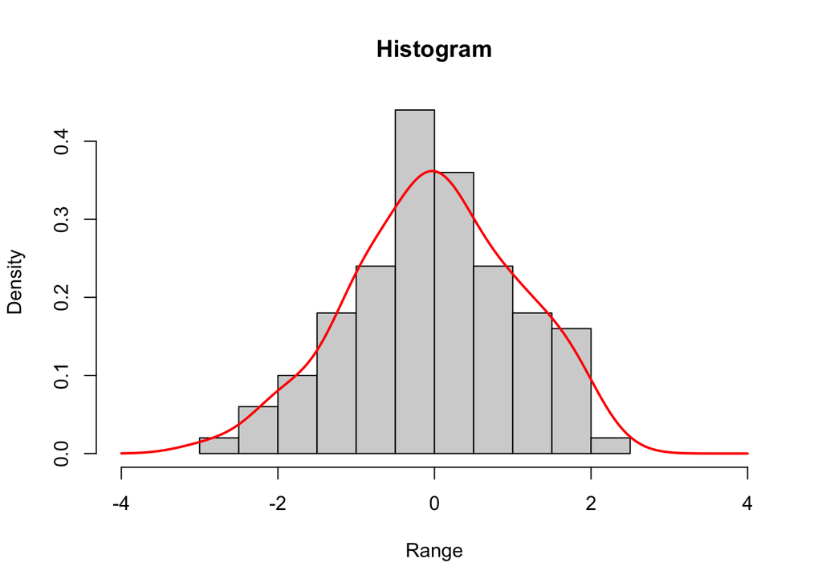

```r
set.seed(341)
z <- rnorm(n = 100)

xrange <- c(-4,4)
h <- 0.9*100^(-1/5)*min(sd(z),IQR(z)/1.34)

hist_density_plot(z,h,xrange,'Range', 'Histogram')
```

## QUESTION 4: R Analysis [21 points]

The *Billboard* Hot 100 is the standard chart used by the American music industry to assess the popularity of songs. The chart has been published weekly by *Billboard* Magazine since August 4, 1958. Each week, the chart ranks the 100 most popular songs based on data from the corresponding tracking period. The chart rankings are based on radio play, online streaming, and physical and digital sales in the United States.

The archive of songs that reach #1 on the chart is well documented (see e.g., [this list](https://en.wikipedia.org/wiki/List_of_Billboard_Hot_100_number_ones_of_2023) for the year 2023). You will work with data from songs that went #1 on the *Billboard* Hot 100 during the $N = 209$ weeks between January 1, 2020 and December 31, 2023. These data are available in the `bh100.csv` file. Each row of this file corresponds to a specific week and the columns and their contents are described below.

[output not shown]

1. [2 points] Using R, read in the data found in `bh100.csv` and create a data frame with a row for each song that indicates how many weeks it spent at #1 on the *Billboard* Hot 100 between January 1, 2020 and December 31, 2023. Then, use the `summary()` function on this variable for the number of weeks and output the results.

```r
data <- read.csv("bh100.csv")
titles = data["Title"]
df <- as.data.frame(table(titles))

summary(df["Freq"])
```

```
##       Freq
##  Min.   : 1.000
##  1st Qu.: 1.000
##  Median : 1.000
##  Mean   : 3.074
##  3rd Qu.: 3.250
##  Max.   :16.000
```

2. [4 points] Let the *population* variance of the number of weeks spent at #1 be the attribute of interest so that $a(\mathcal{P})=\sum_{i = 1}^N(y_i - \bar{y})^2/N$. The influence of song $u$ on $a(\mathcal{P})$ is $\Delta(a,u)$ from the course notes. Construct an influence plot of $\Delta$ vs. the observation number. Identify the song(s) with the largest influence on the population variance attribute and determine their title(s). Based on the data frame you created in part (a), describe why the song(s) have such a large influence.
3. [4 points] Using the `hist_density_plot()` function you created in Question 3, construct a plot that visualizes the histogram and density estimate for the the number of weeks spent at #1 variate. The bandwidth `h` should be determined using Silverman’s “rule of thumb” introduced in Question 3 and `xrange` should be `c(-1, 18)`. Be sure to label the axes and titles informatively. Given your plot, does the histogram or density estimate better summarize the data, and why?

In the remainder of this question, we will explore the density estimate for this data set. We will do so by generating a sample from the distribution with density function $f = \hat{f}$, the estimated density function produced in the previous plot. We will use rejection sampling to obtain this sample.

[Rejection sampling](https://en.wikipedia.org/wiki/Rejection_sampling) transforms a sample from a distribution with density function $g(y)$ into a sample from a distribution with density function $f(y)$. Rejection sampling is useful when it is easy to sample from $g(y)$ but difficult to sample from $f(y)$. Rejection sampling uses a constant $M > 0$ such that $f(y) \le Mg(y)$ for all $y$ to repeatedly implement the following steps:

- Generate $y^* \sim g(y)$ and $u^*$ from the uniform $\mathcal{U}(0,1)$ distribution
- If $u^* \le \dfrac{f(y^*)}{Mg(y^*)}$, keep $y^*$. Otherwise, reject $y^*$.

You will implement rejection sampling in stages over the next parts of this question.

4. [2 points] First, you will generate 50000 $y^*$ values from the uniform $\mathcal{U}(-1,18)$ distribution. This can be done using built-in functions in `base` R. Then, compute $\hat{f}(y^*)$ for each of these values using the `kde_gaussian()` function you created in Question 3 with the bandwidth `h` you computed in part (c) of this question.
5. [3 points] Next, you will generate 50000 $u^*$ values. You will then compute the ratios $f(y^*) \div Mg(y^*)$ from the second bullet point earlier to decide whether to reject or retain the $y^*$ value. You should use $M = 7.25$ and discern $f$ and $g$ based on information provided earlier in this question.
6. [2 points] You will now plot a histogram of your retained $y^*$ values on the relative scale, where the bins for the histogram are unshaded and created using `breaks = "fd"`. The limits for the $x$-axis of this plot should coincide with `xrange` used in part (c) of this question. Remember to include informative titles and axis labels.
7. [3 points] Lastly, you will use the sample of your retained $y^*$ values to estimate $Pr(Y < 1)$, where $Y$ is the random variable with density function $\hat{f}$ from part (c). Based on the formula for the kernel density estimator from Question 2, why is this probability greater than 0 when the Gaussian kernel is used? Briefly, what do the results from this question suggest about using kernel density estimation to summarize data from distributions with bounded support.